# Session 1: R Neotoma refresher

Alistair Seddon

2/20/2020

## Goals

- To download and process data from the Neotoma database, and produce a pollen diagram.
- To import your own datafile and produce a pollen diagram by depth
- To align the data with a newly calculated age depth model and replot the data by age

## Step 1: Install the required libraries (R Packages)

```r
# Libraries
library(neotoma)
library(tidyverse)
library(Bchron)
library(ggpalaeo)
library(rioja)
library(vegan)
```

## Step 2: Do a Neotoma search

```r
pollen.sites <- get_dataset(datasettype = "pollen", gpid = "South Africa")
```

```
## The API call was successful, you have returned 8 records.
```

```r
# Could expand the search and do loc = c c(lonW, latS, lonE, latN)
# Geopolitical units from http://api.neotomadb.org/apdx/geopol.htm

# see ?get_dataset for more information
pollen_data <- pollen.sites %>% get_download()
```

```
## API call was successful. Returned record for Craigrossie
```

```
## API call was successful. Returned record for Elim Swamp
```

```
## API call was successful. Returned record for Klaarfontein Springs
```

```
## API call was successful. Returned record for Vankervelsvlei
```

```
## API call was successful. Returned record for Rietvlei-Still Bay
```

```
## API call was successful. Returned record for Driehoek Vlei
```

```
## API call was successful. Returned record for Sneeuberg Vlei
```

```
## API call was successful. Returned record for Malahlapanga
```

```r
chroncontrol_table <- pollen_data %>% get_chroncontrol()
```

```
## API call was successful. Returned chronology.
## API call was successful. Returned chronology.
## API call was successful. Returned chronology.
## API call was successful. Returned chronology.
## API call was successful. Returned chronology.
## API call was successful. Returned chronology.
## API call was successful. Returned chronology.
## API call was successful. Returned chronology.
```

```r
#save.image("data/input/Neotoma.RData")

# NB If internet isnt' working, we can just load in the image here
# load("data/input/Neotoma.RData")
```

## Can inspect the data that we have downloaded

```r
pollen_data
```

```
## A download_list containing 8 objects:
## Accessed from 2020-03-10 22:43h to 2020-03-10 22:43h.
## Datasets:
##  dataset.id            site.name     long       lat age.younger age.older
##       41627 Craigrossie          28.47147 -28.53103         185     15215
##       41629 Elim Swamp           28.41566 -28.49061       21307     28429
##       46689 Klaarfontein Springs 18.49444 -32.42389         -41      8425
##       46707 Vankervelsvlei       22.90418 -34.01238         567    122885
##       46709 Rietvlei-Still Bay   21.53545 -34.35415         -33     16490
##       46798 Driehoek Vlei        19.16000 -32.44000         -50     15451
##       46806 Sneeuberg Vlei       19.14861 -32.44667         -49     11347
##       46841 Malahlapanga         31.04050 -22.88889         -13      6107
##    type
##  pollen
##  pollen
##  pollen
##  pollen
##  pollen
##  pollen
##  pollen
##  pollen
```

```r
names(pollen_data)
```

```
## [1] "41627" "41629" "46689" "46707" "46709" "46798" "46806" "46841"
```

## Can inspect the data that we have downloaded

```r
chroncontrol_table
```

```
## $`41627`
## Chronology for Craigrossie, dataset ID: 41627
## APD 1: Default model, constructed using OxCal Poisson-process deposition model.
## Model age span: 280 to 13100
## Model age units: Calibrated radiocarbon years BP
##
##   depth thickness   age age.young age.old control.type chron.control.id
## 1   0.0         1   -30       -50     -10     Core top            84400
## 2  84.5         7   660       600     720  Radiocarbon            84401
## 3 176.0        10 10700     10400   11000  Radiocarbon            84402
## 4 181.0        10  9460      9350    9570  Radiocarbon            84403
## 5 301.0        10 10600     10480   10720  Radiocarbon            84404
## 6 471.0        10 10400     10260   10540  Radiocarbon            84405
## 7 491.0        10 10600     10500   10700  Radiocarbon            84406
##
## Accessed 2020-03-10 22:43h.
##
## $`41629`
## Chronology for Elim Swamp, dataset ID: 41629
## APD 1: Default model, constructed using Bacon.
## Model age span: 22180 to 27940
## Model age units: Calibrated radiocarbon years BP
##
##   depth thickness   age age.young age.old control.type chron.control.id
## 1   350        NA 20400     19780   21020  Radiocarbon            84407
## 2   365        NA 21500     21200   21800  Radiocarbon            84408
## 3   540        NA 22600     22360   22840  Radiocarbon            84409
## 4   580        NA 23400     23060   23740  Radiocarbon            84410
##
## Accessed 2020-03-10 22:43h.
##
## $`46689`
## Chronology for Klaarfontein Springs, dataset ID: 46689
## APD 1: Default model, constructed using Bacon.
## Model age span: 50 to 8700
## Model age units: Calibrated radiocarbon years BP
##
##   depth thickness  age age.young age.old control.type chron.control.id
## 1     0        NA  -42       -47     -37     Core top           101310
## 2    25        NA  170       120     220  Radiocarbon           101311
```

[output cut: 84 more lines]

```
## Model age units: Calibrated radiocarbon years BP
##
##   depth thickness  age age.young age.old            control.type
## 1  0.00       0.5  -57       -62     -52                Core top
## 2 55.25       0.5 1145      1070    1265 Radiocarbon, calibrated
## 3 72.25       0.5 5644      5332    5900 Radiocarbon, calibrated
##   chron.control.id
## 1           101887
## 2           101888
## 3           101889
##
## Accessed 2020-03-10 22:43h.
##
## attr(,"class")
## [1] "chroncontrol_list" "list"
```

## Using the `tidyverse` map functions

- These are useful functions to extract the same data objects from different items in a list e.g.

```r
str(pollen.sites[[1]], max.level = 2)
```

```
## List of 5
##  $ site.data   :Classes 'site' and 'data.frame': 1 obs. of  8 variables:
##   ..$ site.id    : int 23950
##   ..$ site.name  : chr "Craigrossie"
##   ..$ long       : num 28.5
##   ..$ lat        : num -28.5
##   ..$ elev       : num 1700
##   ..$ description: chr "Site is an anomalously wet, organic sequence of sediments belonging to a +10-m terrace on the north side of the"| __truncated__
##   ..$ long.acc   : num 0
##   ..$ lat.acc    : num 0
##  $ dataset.meta:'data.frame':    1 obs. of  5 variables:
##   ..$ dataset.id       : int 41627
##   ..$ dataset.name     : logi NA
##   ..$ collection.type  : chr "Section"
##   ..$ collection.handle: chr "CRAIG"
##   ..$ dataset.type     : chr "pollen"
##  $ pi.data     :'data.frame':    1 obs. of  2 variables:
##   ..$ ContactID  : int 262
##   ..$ ContactName: Factor w/ 1 level "Scott, Louis": 1
##  $ submission  :'data.frame':    1 obs. of  2 variables:
##   ..$ submission.date: chr "2019-04-04"
##   ..$ submission.type: chr "Recompilation into Neotoma from another database"
##  $ access.date : POSIXct[1:1], format: "2020-03-10 22:43:31"
##  - attr(*, "class")= chr [1:2] "dataset" "list"
```

```r
map_example <-  map(pollen.sites, "dataset.meta")
map_example
```

```
## $`41627`
##   dataset.id dataset.name collection.type collection.handle dataset.type
## 1      41627           NA         Section             CRAIG       pollen
##
## $`41629`
##   dataset.id dataset.name collection.type collection.handle dataset.type
## 1      41629           NA         Section           ELIMSEQ       pollen
##
## $`46689`
##   dataset.id dataset.name collection.type collection.handle dataset.type
## 1      46689           NA            Core         KLAARFONT       pollen
##
## $`46707`
##   dataset.id dataset.name collection.type collection.handle dataset.type
## 1      46707           NA            Core               VVV       pollen
##
## $`46709`
##   dataset.id dataset.name collection.type collection.handle dataset.type
## 1      46709           NA            Core              RVSB       pollen
##
## $`46798`
##   dataset.id         dataset.name collection.type collection.handle
## 1      46798 Driehoek Vlei pollen            Core          DRIEHOEK
##   dataset.type
## 1       pollen
##
## $`46806`
##   dataset.id          dataset.name collection.type collection.handle
## 1      46806 Sneeuberg Vlei pollen            Core         SNEEUBERG
##   dataset.type
## 1       pollen
##
## $`46841`
##   dataset.id dataset.name collection.type collection.handle dataset.type
## 1      46841           NA            Core        MALAHLAPAN       pollen
```

```r
map_df_example <- map_df(pollen.sites, "dataset.meta")
map_df_example
```

```
##   dataset.id          dataset.name collection.type collection.handle
## 1      41627                  <NA>         Section             CRAIG
## 2      41629                  <NA>         Section           ELIMSEQ
## 3      46689                  <NA>            Core         KLAARFONT
## 4      46707                  <NA>            Core               VVV
## 5      46709                  <NA>            Core              RVSB
## 6      46798  Driehoek Vlei pollen            Core          DRIEHOEK
## 7      46806 Sneeuberg Vlei pollen            Core         SNEEUBERG
## 8      46841                  <NA>            Core        MALAHLAPAN
##   dataset.type
## 1       pollen
## 2       pollen
## 3       pollen
## 4       pollen
## 5       pollen
## 6       pollen
## 7       pollen
## 8       pollen
```

## Build a table with required metadata information

Can use the mapdf function in a pipe to extract information from the pollen.site table Things we probably need will be dataset.id, lat, long, elevation.

```r
# Gives the dataset information
dataset_info <- pollen.sites %>%
              map_df("dataset.meta") %>%
              bind_cols(pollen.sites %>%  map_df("site.data")) %>%
              select(dataset.id, site.id, site.name,
                     collection.handle, collection.type,
                     long, lat, elev)
dataset_info
```

```
##   dataset.id site.id            site.name collection.handle collection.type
## 1      41627   23950          Craigrossie             CRAIG         Section
## 2      41629   23951           Elim Swamp           ELIMSEQ         Section
## 3      46689   26661 Klaarfontein Springs         KLAARFONT            Core
## 4      46707   26668       Vankervelsvlei               VVV            Core
## 5      46709   26669   Rietvlei-Still Bay              RVSB            Core
## 6      46798   26737        Driehoek Vlei          DRIEHOEK            Core
## 7      46806   26739       Sneeuberg Vlei         SNEEUBERG            Core
## 8      46841   26755         Malahlapanga        MALAHLAPAN            Core
##       long       lat elev
## 1 28.47147 -28.53103 1700
## 2 28.41566 -28.49061 1890
## 3 18.49444 -32.42389    2
## 4 22.90418 -34.01238  153
## 5 21.53545 -34.35415   17
## 6 19.16000 -32.44000  900
## 7 19.14861 -32.44667 1440
## 8 31.04050 -22.88889   NA
```

## Step 3: Extract the count data for a single site/ multiple sites

```r
x <- pollen_data[[1]] # Access the first object in the get_download object

# gives the same as:
x <- pollen_data[["41627"]]
str(x, max.level = 1)  # this shows how to access all the information you would need from the pollen data object
```

```
## List of 6
##  $ dataset     :List of 6
##   ..- attr(*, "class")= chr [1:2] "dataset" "list"
##  $ sample.meta :'data.frame':    29 obs. of  11 variables:
##  $ taxon.list  :'data.frame':    50 obs. of  6 variables:
##  $ counts      : num [1:29, 1:50] 16 0 0 6 3 19 5 7 6 18 ...
##   ..- attr(*, "dimnames")=List of 2
##  $ lab.data    : logi[1:29, 0 ]
##   ..- attr(*, "dimnames")=List of 2
##  $ chronologies:List of 1
##  - attr(*, "class")= chr [1:2] "download" "list"
```

```r
counts <- x$counts
# Or you can use the Neotoma function to extract the counts
counts<- neotoma::counts(x)
head(counts)
```

```
##        Amaranthaceae Anemia Anthospermum Artemisia Asteraceae undiff. Crassula
## 350781            16      3            2         8                 24        1
## 350782             0      1            0         7                  6        0
## 350783             0      0            0         4                  2        0
## 350784             6      0            0        21                  7        1
## 350785             3      2            0         5                  8        0
## 350786            19      0            6        53                 48        0
##        Cyperaceae Gunnera Liliaceae Ophioglossum Pinus Poaceae Podocarpus
## 350781        117       2         1            1     1      60          2
## 350782        120       1         0            0     2     158          0
## 350783        335      11         3            0     0      32          0
## 350784        125      14         0            0     0      43          1
## 350785        169      23         0            0     0      23          1
## 350786         29       1         0            0     0      73          0
##        Pteridophyta Rhus Riccia Selaginella Typha Unknown Anthoceros
```

[output cut: 41 more lines]

```r
# Can use map to access all the counts and store as a list
count_data <- pollen_data %>% map("counts")

# NB. This gives the same as:
# count_data <-  lapply(pollen_data, neotoma::counts)
```

## Build a table with required metadata information

```r
  count_data <- pollen_data %>% map("counts")
  taxa_data <-   pollen_data %>% map("taxon.list")
  pollen_count_tibble <- tibble( dataset.id = as.numeric(names(count_data)),
                                     count_data = count_data,
                                     taxa_data = taxa_data,
                                     sample_meta_data = map(pollen_data, "sample.meta")
                                    )


# Combine them into one useful tibble (dataset_info object created previously)
  pollen_SA_tibble <- left_join(pollen_count_tibble, dataset_info,  by = "dataset.id")
```

Now we have all the counts, sample data and taxa data in one useable tibble

```r
pollen_SA_tibble
```

```
## # A tibble: 8 x 11
##   dataset.id count_data taxa_data sample_meta_data site.id site.name
##        <dbl> <list>     <list>    <list>             <int> <chr>
## 1      41627 <dbl[,50]… <df[,6] … <df[,11] [29 × …   23950 Craigros…
## 2      41629 <dbl[,36]… <df[,6] … <df[,11] [29 × …   23951 Elim Swa…
## 3      46689 <dbl[,48]… <df[,6] … <df[,11] [37 × …   26661 Klaarfon…
## 4      46707 <dbl[,87]… <df[,6] … <df[,11] [43 × …   26668 Vankerve…
## 5      46709 <dbl[,92]… <df[,6] … <df[,11] [58 × …   26669 Rietvlei…
## 6      46798 <dbl[,35]… <df[,6] … <df[,11] [98 × …   26737 Driehoek…
## 7      46806 <dbl[,38]… <df[,6] … <df[,11] [63 × …   26739 Sneeuber…
## 8      46841 <dbl[,67]… <df[,7] … <df[,11] [37 × …   26755 Malahlap…
## # … with 5 more variables: collection.handle <chr>, collection.type <chr>,
## #   long <dbl>, lat <dbl>, elev <dbl>
```

## Plotting a simple stratigraphic diagram for a single site

Select an indvidual site with collection handle `KLAARFONT`

```r
# Let's do it for a single site
x <- pollen_SA_tibble %>% filter(collection.handle == "KLAARFONT")
x
```

```
## # A tibble: 1 x 11
##   dataset.id count_data taxa_data sample_meta_data site.id site.name
##        <dbl> <list>     <list>    <list>             <int> <chr>
## 1      46689 <dbl[,48]… <df[,6] … <df[,11] [37 × …   26661 Klaarfon…
## # … with 5 more variables: collection.handle <chr>, collection.type <chr>,
## #   long <dbl>, lat <dbl>, elev <dbl>
```

## Plotting a simple stratigraphic diagram for a single site

```r
# get our information from our tibble
cnts <- x$count_data[[1]] %>%
  as.data.frame() %>%
  rownames_to_column(var= "sample.id")

meta <- x$sample_meta_data[[1]] %>%
  select(sample.id, age, depth) %>%
  mutate(sample.id = as.character(sample.id))

taxa <- x$taxa_data[[1]] %>% mutate_all(as.character)

# Create a long-version of the table
site_to_plot <- meta %>%
  left_join(cnts, by= "sample.id") %>%
  select(-sample.id) %>%
  pivot_longer(cols = -c("age", "depth"), names_to = "taxon.name", values_to = "count") %>%
  left_join(taxa, by = "taxon.name")
```

Now is a good time to check taxa/ ecological groups we have. It’s useful to have the [Neotoma database manual](https://www.neotomadb.org/uploads/NeotomaManual.pdf) open to check what terms mean.

```r
site_to_plot %>% count(variable.element)
```

```
## # A tibble: 2 x 2
##   variable.element     n
##   <chr>            <int>
## 1 pollen            1702
## 2 spore               74
```

```r
eco_types <- get_table("EcolGroupTypes")
eco_types %>%
  semi_join(site_to_plot, by = c("EcolGroupID" = "ecological.group")) %>%
  select(EcolGroupID, EcolGroup)
```

```
##   EcolGroupID                               EcolGroup
## 1        AQVP                 Aquatic Vascular Plants
## 2        SEED Spermatophyte rank or clade above order
## 3        TRSH                        Trees and Shrubs
## 4        UPHE                            Upland Herbs
## 5        VACR         Terrestrial Vascular Cryptogams
```

```r
site_to_plot %>% filter(ecological.group == "SEED", count > 0) %>%
  select(taxon.name, count) %>%
  group_by(taxon.name) %>%
  summarise(n = n(), max = max(count))
```

```
## # A tibble: 1 x 3
##   taxon.name                n   max
##   <chr>                 <int> <dbl>
## 1 Spermatophyta undiff.    37    58
```

```r
#remove unwanted variable.element/ecological.group
site_to_plot <- site_to_plot %>%
  filter(!ecological.group %in% c("SEED"))
#use `%in%` not `==`
```

What about `VACR`/ `AQVP`?

```r
#remove unwanted variable.element/ecological.group
site_to_plot %>% filter(ecological.group == "VACR" | ecological.group == "AQVP", count > 0) %>%
  select(taxon.name, count) %>%
  group_by(taxon.name) %>%
  summarise(n = n(), max = max(count))
```

```
## # A tibble: 7 x 3
##   taxon.name         n   max
##   <chr>          <int> <dbl>
## 1 Aponogeton        21     9
## 2 cf. Pteridium     21    26
## 3 Drosera           28    21
## 4 Juncus            31    83
## 5 Myriophyllum       9    11
## 6 Polypodiophyta    37    40
## 7 Typha             21    54
```

```r
# I'm going to delete them so we just have pollen
site_to_plot <- site_to_plot %>%
  filter(!ecological.group %in% c("VACR", "AQVP"))
```

This is a good time to check the count sums. It might be prudent to delete any samples with very low counts, but in this site the count sums are all greater than 200

```r
#check count sums
site_to_plot %>%
  group_by(depth) %>%
  summarise(s = sum(count)) %>%
  arrange(s) %>%
  slice(1:5)
```

```
## # A tibble: 5 x 2
##   depth     s
##   <dbl> <dbl>
## 1   475   214
## 2   322   220
## 3   424   233
## 4   376   238
## 5    75   248
```

```r
site_to_plot %>%
  group_by(depth) %>%
  summarise(s = sum(count)) %>%
  arrange(desc(s)) %>%
  slice(1:5)
```

```
## # A tibble: 5 x 2
##   depth     s
##   <dbl> <dbl>
## 1    10   665
## 2   200   601
## 3   210   565
## 4   187   515
## 5    55   494
```

Now we can calculate percent and remove the rare taxa

```r
#calculate percent
site_to_plot <- site_to_plot %>%
  group_by(depth) %>%
  mutate(percent = count/sum(count) * 100)
#remove rare taxa
site_to_plot1 <- site_to_plot %>%
  group_by(taxon.name) %>%
  filter(
    sum(percent > 0) >= 3, #must be in at least three samples
    max(percent) > 3) #must have a max percent > 3
```

Now we can use `pivot_wider` to reshape the data back into a species x samples data.frame that we can plot with `rioja::strat.plot`. For convenience, I’m separating the species data from the age/depth data.

```r
site_to_plot2 <- site_to_plot1 %>%
  select(age, depth, taxon.name, percent) %>%
  pivot_wider(names_from = "taxon.name", values_from = "percent")
site_to_plot_spp <- site_to_plot2 %>% select(-age, -depth) %>%
  as.data.frame() #needed as strat.plot does not like tibble
```

Now we can plot the stratigraphy.

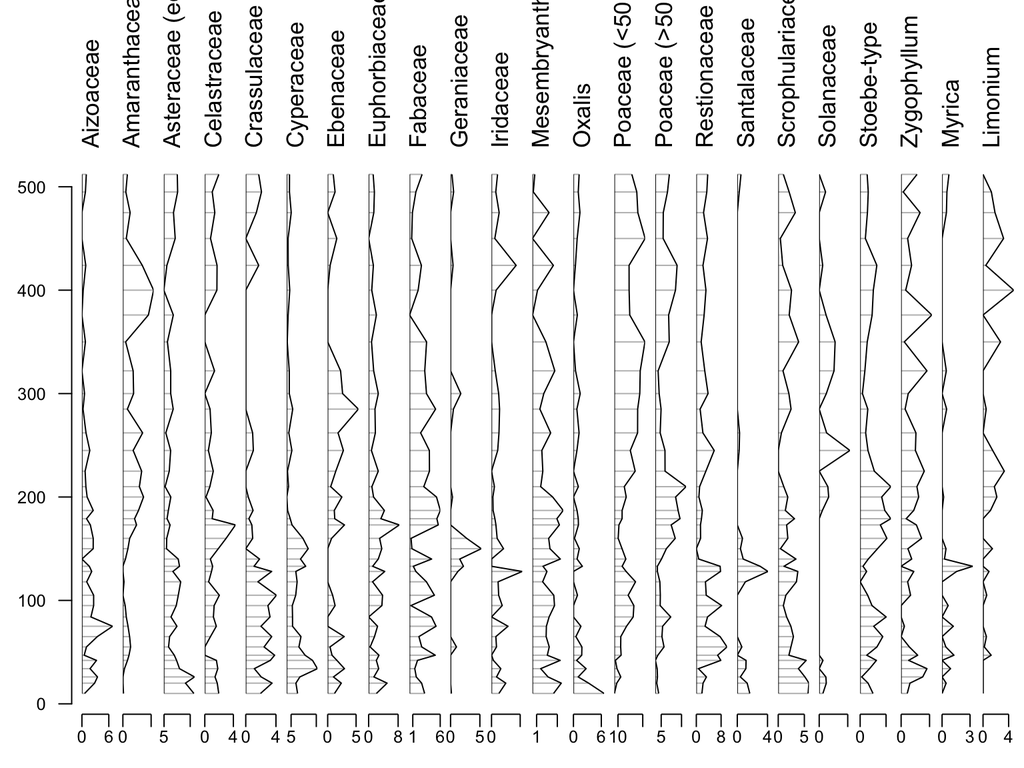

```r
#strat.plot
strat.plot(site_to_plot_spp, yvar = site_to_plot2$depth)
```

There are many options we can use to change this, and these were covered in the previous workshop. For example, ordering by the species group and by the maximum abundance in the core would be one option.

We could also run a constrained cluster analysis

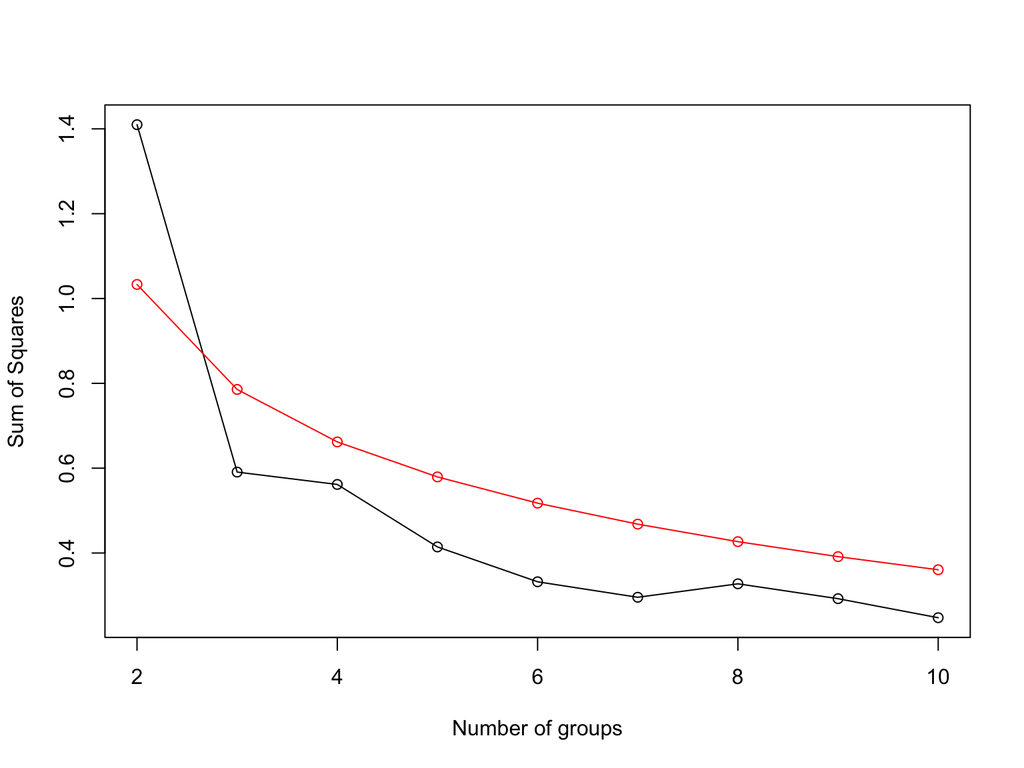

```r
site_to_plot_dist <- dist(sqrt(site_to_plot_spp /100))#chord distance
clust <- chclust(site_to_plot_dist , method = "coniss")
bstick(clust)#two  groups
```

Now we can make a better plot.

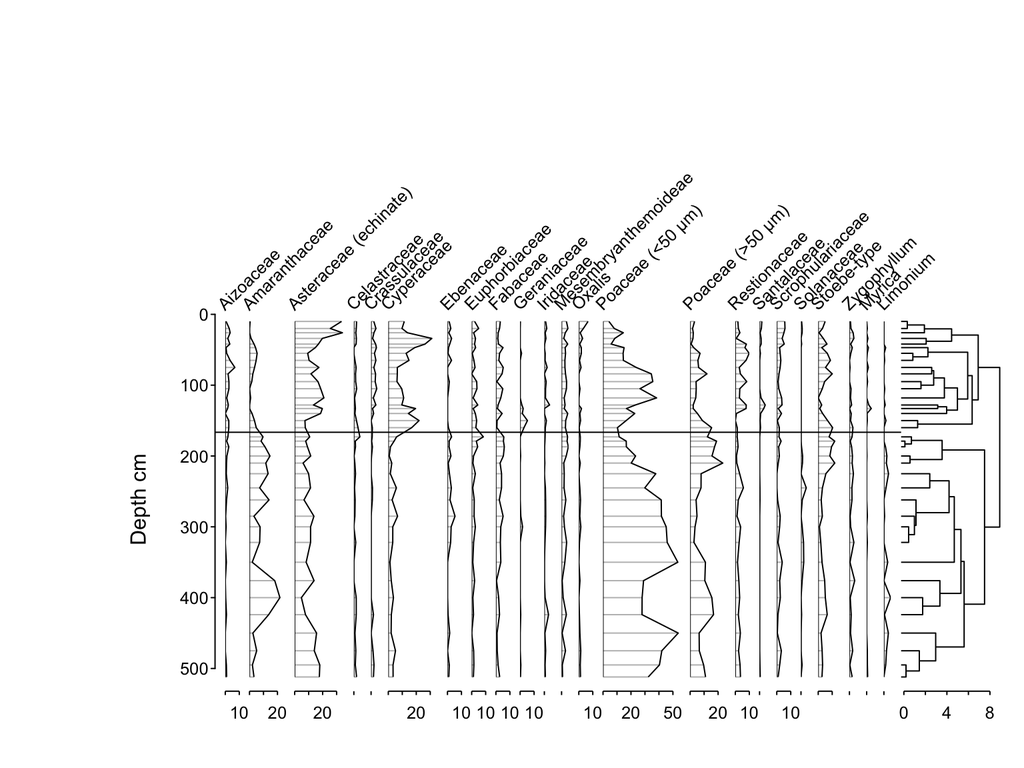

```r
#set up mgp (see ?par)
mgp <- c(2, 0.25, 0)
par(tcl = -0.15, mgp = mgp)#shorter axis ticks - see ?par
pt <- strat.plot(
  d = site_to_plot_spp,
  yvar = site_to_plot2$depth,
  y.rev = TRUE, #reverse direction of y-axis
  scale.percent = TRUE, #use constant scale for all taxa
  srt.xlabel = 45, #rotate x-label by 45 degrees
  cex.xlabel = 0.8, #smaller font
  mgp = mgp,
  xRight = 0.98, #right margin
  xLeft = 0.21, #left margin with space for 2nd axis
  yTop = 0.60, #top margin
  yBottom = 0.1, #bottom margin
  ylabel = "Depth cm",
  clust = clust
  )
#add zone boundaries
addClustZone(pt, clust = clust, nZone = 2)
```

```r
#add a secondary scale
# secondary_scale(pt, yvar = site_to_plot2$depth, yvar2 = site_to_plot2$age, ylabel2 = "Date yr BP", n = 10)
```

## Other exercises

This is a basic introduction/ recap to plotting a palaeoecological stratgraphic data in R.

- Repeat the process for a different site in the Neotoma Database. Make a stratigraphic plot and for these data and document the decisions that you make along the way.
- Run a principle components analysis on the palaeoecological dataset and plot the first principle coordinate axes against time
1. Extract a long-table by depth and age and filter so that only the abundant taxa are used

```r
site_to_pca <- site_to_plot2 %>% select(-age, -depth)
depth <-site_to_plot2$depth
age <-site_to_plot2$age
```

2. Use vegan::rda or princomp to fit the principle components model

```r
pca_mod <- vegan::rda(site_to_pca)
summary(pca_mod)
```

```
##
## Call:
## rda(X = site_to_pca)
##
## Partitioning of variance:
##               Inertia Proportion
## Total           390.9          1
## Unconstrained   390.9          1
##
## Eigenvalues, and their contribution to the variance
##
## Importance of components:
##                            PC1     PC2      PC3     PC4     PC5    PC6     PC7
## Eigenvalue            224.4341 91.9278 30.23203 14.6209 9.21682 5.4745 2.79497
## Proportion Explained    0.5741  0.2352  0.07733  0.0374 0.02358 0.0140 0.00715
## Cumulative Proportion   0.5741  0.8093  0.88659  0.9240 0.94757 0.9616 0.96872
##                            PC8      PC9     PC10     PC11     PC12     PC13
## Eigenvalue            1.963126 1.706643 1.647858 1.193992 1.136837 0.986720
## Proportion Explained  0.005022 0.004366 0.004215 0.003054 0.002908 0.002524
## Cumulative Proportion 0.973745 0.978110 0.982326 0.985380 0.988288 0.990812
##                           PC14     PC15     PC16     PC17      PC18      PC19
## Eigenvalue            0.727690 0.678196 0.577592 0.454847 0.3874649 0.2454314
## Proportion Explained  0.001861 0.001735 0.001477 0.001164 0.0009911 0.0006278
## Cumulative Proportion 0.992673 0.994408 0.995886 0.997049 0.9980404 0.9986682
##                            PC20      PC21      PC22      PC23
## Eigenvalue            0.2072532 0.1834708 0.0831956 0.0467208
## Proportion Explained  0.0005302 0.0004693 0.0002128 0.0001195
## Cumulative Proportion 0.9991984 0.9996677 0.9998805 1.0000000
##
## Scaling 2 for species and site scores
## * Species are scaled proportional to eigenvalues
## * Sites are unscaled: weighted dispersion equal on all dimensions
## * General scaling constant of scores:  10.89181
##
##
## Species scores
##
##                             PC1       PC2       PC3       PC4       PC5
## Aizoaceae              0.351939 -0.046363  0.020230 -0.150370  0.247400
## Amaranthaceae         -0.935305  2.390007  0.098132  1.624854 -0.417994
```

[output cut: 72 more lines]

```
## sit23 -0.04468  3.9188  0.762965 -2.49831 -1.5391 -2.0177
## sit24 -1.81447  0.8242  0.068717  2.35354  0.1225  0.7072
## sit25 -0.65851  0.2280 -0.301889  0.91782  1.4471 -0.7682
## sit26 -2.21530  0.3157 -1.249087  3.60692  0.5361  2.1601
## sit27 -1.74875 -1.3741 -0.561720 -0.55420 -0.6470  2.8269
## sit28 -2.37237 -1.0829 -0.677750  1.65517  0.7504  1.7313
## sit29 -2.45158 -1.1405 -0.715728  1.63804  0.4444  2.2040
## sit30 -3.43169 -0.8026 -0.970615 -2.96981 -0.5567  0.4565
## sit31 -0.83580  1.5072  1.456087  4.10724 -2.0149 -1.8863
## sit32 -0.96506  3.2156 -0.584019  3.82007 -1.9267 -2.4726
## sit33 -0.82532  2.5161  0.447902  0.30240 -0.6041 -0.9310
## sit34 -3.24890 -2.0435 -0.005301 -1.18237 -1.0880 -1.7601
## sit35 -1.86554 -1.0651 -0.181160 -0.06890 -1.0090 -0.1934
## sit36 -1.66782 -1.2080  1.199207 -1.85957 -0.7332 -1.8035
## sit37 -0.84391 -0.4652  1.662147 -1.41859 -0.3322 -1.6640
```

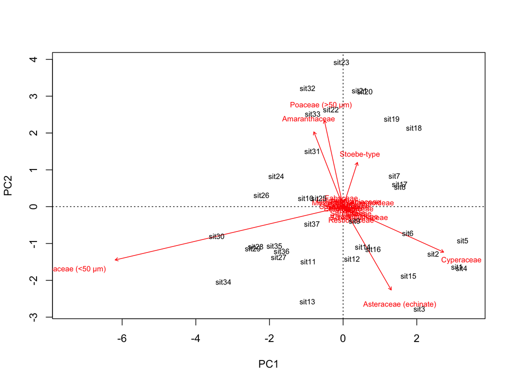

```r
biplot(pca_mod)
```

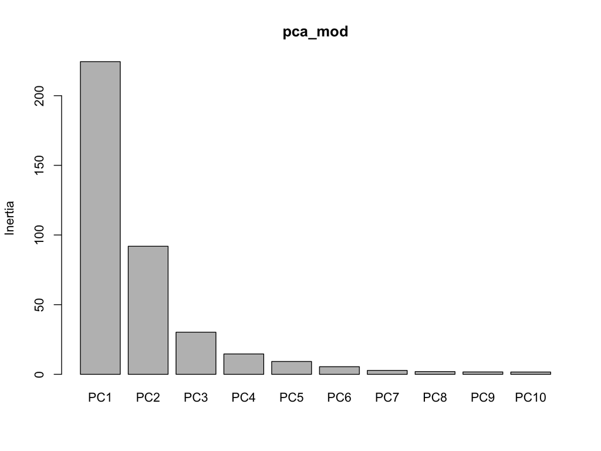

```r
screeplot(pca_mod)
```

3. Extract the sample scores, convert to tibble and add the ages, then change to long-table format

```r
sample_scores <- scores(pca_mod)$sites %>%
  as_tibble() %>%
  mutate(age = age, depth = depth) %>%
  pivot_longer(cols = c("PC1", "PC2"), names_to = "PC_axis", values_to = "PC_units")
```

```r
pca_plot_time <- sample_scores %>%
  ggplot(aes(x = age, y = PC_units, group = PC_axis)) +
  geom_point() +
  geom_line() +
  facet_grid(PC_axis~.)
```

Use the chron control table to make a new set of age models for a site using BACON.

1. Get chron control tibble for a given site and align with the pollen data

```r
library(rbacon)
chroncontrol_tibble <- tibble( dataset.id = as.numeric(names(chroncontrol_table)),
                                     chron_control = map(chroncontrol_table, "chron.control")
                                    )
pollen_SA_tibble <- pollen_SA_tibble %>% left_join(chroncontrol_tibble, by= "dataset.id")
```

2. Extract the chron control table for the site of interest and rewrite it for BACON

```r
handle_want <- "KLAARFONT"
dir.create(paste0("Plum_runs/", handle_want))
```

```r
x <- pollen_SA_tibble %>% filter(collection.handle == handle_want) %>% select(chron_control)

bacon_col_names <- c("labID", "age", "error", "depth")
bacon_table <- tibble(labID = x[[1]][[1]]$chron.control.id,
                      age = x[[1]][[1]]$age,
                      error = (x[[1]][[1]]$age.old - x[[1]][[1]]$age.young),
                      depth = x[[1]][[1]]$depth,
                      control.type = x[[1]][[1]]$control.type) %>%
  mutate(cc = 0) %>%
  mutate(cc = replace(cc, control.type == "Radiocarbon", 3 )) %>% # Southern hemisphere curve
  select(-control.type)

#write_csv(bacon_table, path = paste0("Plum_runs/", handle_want,"/",handle_want, ".csv"))
```

3. Run the age modelling algorithm

```r
# Bacon(core = handle_want,
#       depths = depth,
#       thick = 20
#       )
```

4. Import the new age and depth information

```r
newAges <- read_delim(paste0("Plum_runs/", handle_want,"/",handle_want, "_26_ages.txt"), delim = "\t")
```

6. Replot using these dates instead

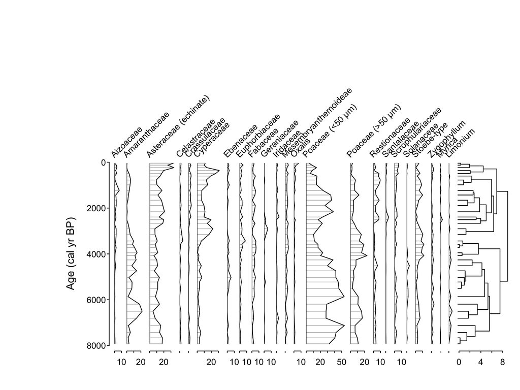

```r
mgp <- c(2, 0.25, 0)
par(tcl = -0.15, mgp = mgp)#shorter axis ticks - see ?par
pt_age <- strat.plot(
  d = site_to_plot_spp,
  yvar = newAges$median,
  y.rev = TRUE, #reverse direction of y-axis
  scale.percent = TRUE, #use constant scale for all taxa
  srt.xlabel = 45, #rotate x-label by 45 degrees
  cex.xlabel = 0.8, #smaller font
  mgp = mgp,
  xRight = 0.98, #right margin
  xLeft = 0.21, #left margin with space for 2nd axis
  yTop = 0.60, #top margin
  yBottom = 0.1, #bottom margin
  ylabel = "Age (cal yr BP)",
  clust = clust
  )
```

4. Make a function which can automatically plot a simple stratigraphic diagram for any site and save it in a directory in the project folder. This is useful for inspecting sites later when doing multi-site syntheses.

There are two general methods to perform PCA in R :

Spectral decomposition which examines the covariances / correlations between variables Singular value decomposition which examines the covariances / correlations between individuals The function princomp() uses the spectral decomposition approach. The functions prcomp() and PCA()[FactoMineR] use the singular value decomposition (SVD).

Arguments for prcomp(): x: a numeric matrix or data frame scale: a logical value indicating whether the variables should be scaled to have unit variance before the analysis takes place Arguments for princomp(): x: a numeric matrix or data frame cor: a logical value. If TRUE, the data will be centered and scaled before the analysis scores: a logical value. If TRUE, the coordinates on each principal component are calculated